# Milestone Report

Shadi

6/22/2020

## Summary

The goal of this project is to show the mastrey in dealing with the data, and that data scientist is on track to create precise prediction algorithm for text models like those used by SwiftKey. Text data is collected from publicly available sources by a web crawler, and it is available in coursera. The data consist of 3 text files containing text from three different sources (blogs, news & twitter), and it is availbale in 4 languages. we focus our analysis on english data set.

## Exploratory Analysis

we start by loading data and library

### Load Library and data

```r
library(magrittr)
library(stringi)
library(ggplot2)
library(tm)
library(RWeka)



blogs<-readLines("en_US.blogs.txt",encoding="UTF-8", skipNul = TRUE)
news<-readLines("en_US.news.txt",encoding="UTF-8", skipNul = TRUE)
twitter<-readLines("en_US.twitter.txt",encoding="UTF-8", skipNul = TRUE)
```

## Exploratory analysis

We continue our analysis by providing summary stataistic and histogram for of blog, twitter and news

### Statistics

Summary statistic of raw data is provided below.

```r
words_blogs <- stri_count_words(blogs)
words_news <- stri_count_words(news)
words_twitter <- stri_count_words(twitter)
size_blogs <- file.info("en_US.blogs.txt")$size/1024^2
size_news <- file.info("en_US.news.txt")$size/1024^2
size_twitter <- file.info("en_US.twitter.txt")$size/1024^2
summary_table <- data.frame(filename = c("blogs","news","twitter"),
                            file_size_MB = c(size_blogs, size_news, size_twitter),
                            num_lines = c(length(blogs),length(news),length(twitter)),
                            num_words = c(sum(words_blogs),sum(words_news),sum(words_twitter)),
                            mean_num_words = c(mean(words_blogs),mean(words_news),mean(words_twitter)))
summary_table
```

```
##   filename file_size_MB num_lines num_words mean_num_words
## 1    blogs     200.4242    899288  37546239       41.75107
## 2     news     196.2775   1010242  34762395       34.40997
## 3  twitter     159.3641   2360148  30093413       12.75065
```

looking at initial statistics we see that our data size is so big; therefore to prevent difficulty in calcutlation we take a sample of our data set with 1% size of it is original size

```r
set.seed(1)
blogsSample <- sample(blogs, length(blogs)*0.01)
newsSample <- sample(news, length(news)*0.01)
twitterSample <- sample(twitter, length(twitter)*0.01)
```

### Plots

Before preparing our data for analysis, we take a look at the histogram of data per line for each file.

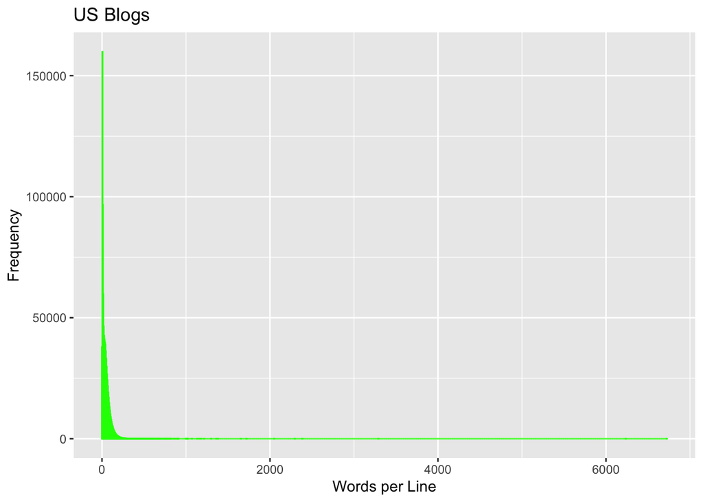

```r
wpl <- lapply(list(blogs, news, twitter), function(x) stri_count_words(x))


plot1 <- qplot(wpl[[1]],
               geom = "histogram",
               main = "US Blogs",
               xlab = "Words per Line",
               ylab = "Frequency",
               binwidth = 5,
               colour = I("green"))

plot2 <- qplot(wpl[[2]],
               geom = "histogram",
               main = "US News",
               xlab = "Words per Line",
               ylab = "Frequency",
               colour = I("Yellow") ,
               binwidth = 5)

plot3 <- qplot(wpl[[3]],
               geom = "histogram",
               main = "US Twitter",
               xlab = "Words per Line",
               ylab = "Frequency",
               binwidth = 1,
               colour = I("blue"))

plot1
```

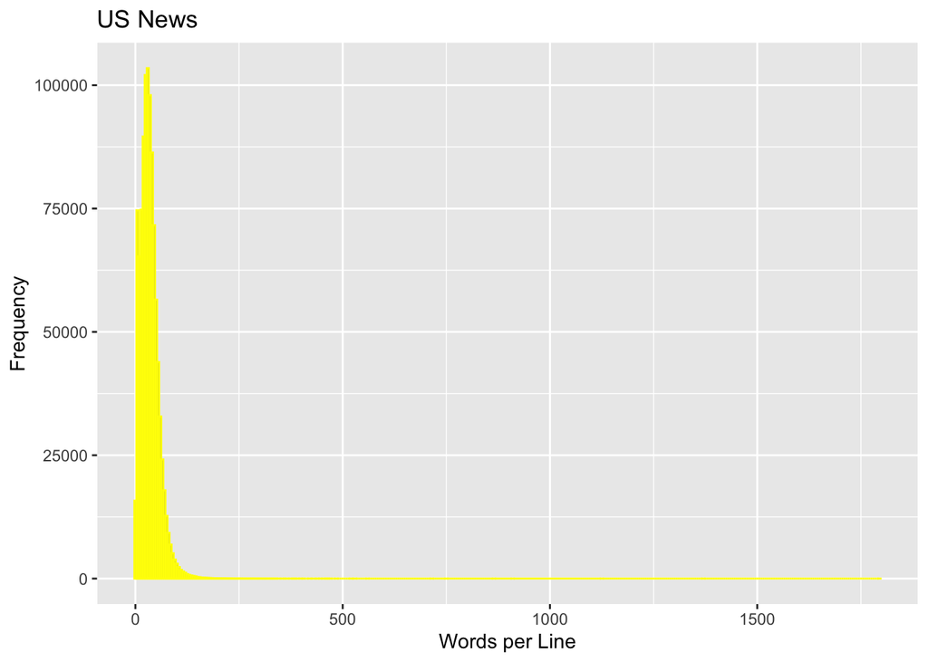

```r
plot2
```

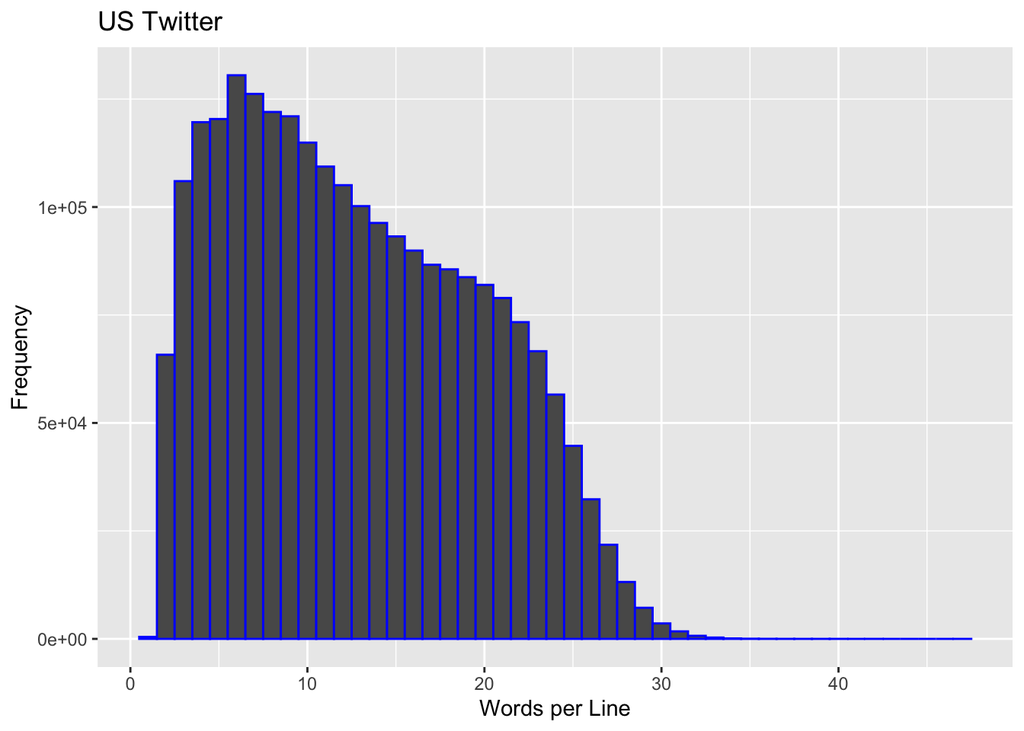

```r
plot3
```

```r
rm(plot1, plot2, plot3)
```